# Mass Shootings in America: A Modern Deconstruction

## 3. Data Exploration and Analysis

Data exploration and visualization is key to any data science project. Most of the plots here have been generated by matplot and pandas

## 3.1 The Number of Mass Shootings per Year

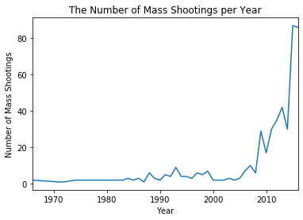

```python
m = ag.groupby(ag['DateTime'].dt.year).size().plot(title="The Number of Mass Shootings per Year")
m.set_ylabel("Number of Mass Shootings")
m.set_xlabel("Year")
```

The number of mass shootings in the United States has reached an all time high. Almost every 9 days there is a mass shooting where there are 5 or more victims. Around 2006 is when the rate of mass shootings begin to increase almost quadratically.

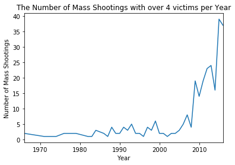

```python
m = ag[ag['Total Victims'] > 4].groupby(ag['DateTime'].dt.year).size().plot(title="The Number of Mass Shootings with over 4 victims per Year")

m.set_ylabel("Number of Mass Shootings")
m.set_xlabel("Year")
```

With this rapid spike of mass shootings, one might beging to wonder the wonder the mean number of fatatlities per mass shootings by year. It seems as though the mean number of fatalities has little correlation with the year.

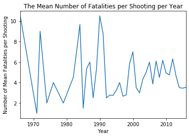

```python
m = ag.groupby(ag['DateTime'].dt.year)['Fatalities'].mean().plot(title="The Mean Number of Fatalities per Shooting per Year")

m.set_ylabel("Number of Mean Fatalities per Shooting")
m.set_xlabel("Year")
```

Surprisingly, the mean number of victims per year is on a slight negative trend. This may be because people are more aware of mass shootings and can more adequately protect themselves. Many institutions now have procedures in place to handle mass shootings. The constant connectivity of social media and the internet also provides a way for people to stay aware of potential threats.

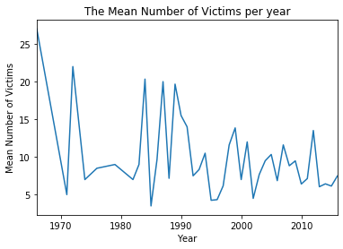

```python
m = ag.groupby(ag['DateTime'].dt.year)['Total Victims'].mean().plot(title="The Mean Number of Victims per year")

m.set_ylabel("Mean Number of Victims")
m.set_xlabel("Year")
```

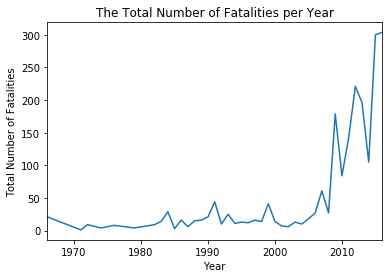

```python
m = ag.groupby(ag['DateTime'].dt.year)['Fatalities'].sum().plot(title="The Total Number of Fatalities per Year")

m.set_ylabel("Total Number of Fatalities")
m.set_xlabel("Year")
```

## 3.2 School Related Shootings

In this section, only two of the three sources have information about school related mass shootings. And to account for that, one can discount the the source without school related data to prevent a skew. Panda's documentation on dropna goes in more detail: https://pandas.pydata.org/pandas-docs/stable/reference/api/pandas.DataFrame.dropna.html

It is interesting that although the number of mass shooting increases, the number of school related shootings stays about the same. Perhaps this means that students are going through less social upheaval.

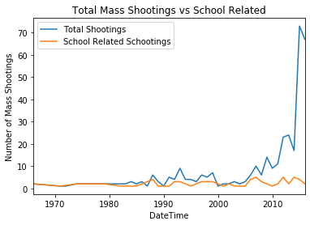

```python
fig, ax = plt.subplots()
trim_na = ag.dropna(subset=['School Related'])
ag.groupby(trim_na['DateTime'].dt.year).size().plot(title="Total Mass Shootings vs School Related", ax=ax)
ax.set_ylabel("Number of Mass Shootings")
ax.set_xlabel("Year")

trim_sch = trim_na[trim_na['School Related']]
ag.groupby(trim_sch['DateTime'].dt.year).size().plot(ax=ax)
ax.legend(['Total Shootings', 'School Related Schootings'])
```

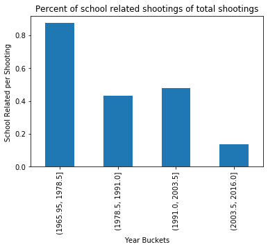

```python
trim_na['bucket'] =  pd.cut(trim_na['DateTime'].dt.year, 4)
trim_sch['bucket'] =  pd.cut(trim_sch['DateTime'].dt.year, 4)
per_sch = trim_sch.groupby(trim_sch['bucket']).size()/trim_na.groupby(trim_na['bucket']).size()
per_sch
per_sch.fillna(0, inplace=True)
m = per_sch.plot(kind='bar', title='Percent of school related shootings of total shootings')
m.set_ylabel('School Related per Shooting ')
m.set_xlabel('Year Buckets')
```

Althought the number of school realated shootings has stayed relatively consistent, the total number of shottings has dramatically increased recently. This means that if we look at the proportion of schootings that are school realted compared to the total, there is a strnog downward trend. School shootings are very dramatic so they are likely to be recorded even when the public isnt paying as close attension to the issue. In recent times we are more cognisant of this issue, so this trend may be due to the fact we are just recording less pronouced shootings more often.

## 3.3 Race Analysis

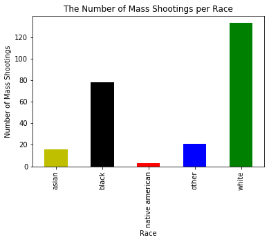

```python
trim_race = ag.dropna(subset=['Race'])
trim_race = trim_race[trim_race['Race'] != 'unclear']
my_colors = list(['y', 'k', 'r', 'b', 'g'])

m = trim_race.groupby(ag['Race']).size().plot(kind='bar', title="The Number of Mass Shootings per Race", color=my_colors)
m.set_ylabel("Number of Mass Shootings")
m.set_xlabel("Race")
```

Doing a basic graphing of what races are commiting the mass shootings we can see that, Caucasians are doing the majority of the work. This might reinforce the image of the classic school schooter in your head. However, this does not tell the full story, seeing as the majority of the US is still white. To get a more accurate picure of what races are likely to commit mass shootings, lets try to normalize the data.

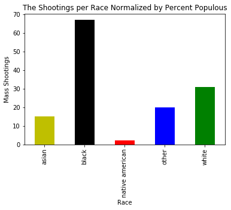

```python
r_pop = pd.read_csv('QuickFacts Dec-16-2019.csv')
r_pop = r_pop.loc[8:12]
r_pop['United States'] = r_pop['United States'].str.replace(',', '')
r_pop['United States'] = r_pop['United States'].str.replace('%', '').astype('float')
r_pop.reset_index(drop=True, inplace=True)

trim_race = ag.dropna(subset=['Race'])
trim_race = trim_race[trim_race['Race'] != 'unclear']
my_colors = list(['y', 'k', 'r', 'b', 'g'])

race_count = trim_race.groupby(ag['Race']).size()
race_count['white'] *= 1- (r_pop.iloc[0]['United States'] / 100)
race_count['black'] *= 1- (r_pop.iloc[1]['United States'] / 100)
race_count['native american'] *= 1- (r_pop.iloc[2]['United States'] / 100)
race_count['asian'] *= 1- (r_pop.iloc[3]['United States'] / 100)
race_count['other'] *= 1- (r_pop.iloc[4]['United States'] / 100)


m = race_count.plot(kind='bar', title="The Shootings per Race Normalized by Percent Populous", color=my_colors)
m.set_ylabel("Mass Shootings")
m.set_xlabel("Race")
```

Here I took some Census data on the percentage of different races within the US. Multiplying the number of mass shootings by each race by 1 minues the percent of that race in the US gives us a normalized graph. This new graph tells quite a different story, Caucaisans are not responsible for substantially more mass shootings if we take into account the population within the us. This new graph shows us that you cannot really pin the rise in shootings to one race or poeple. It is an overall increase and shooter are most likely a product of their circumstance.

### HeatMaps and ChoroPleths

```python
trim_ag = ag[ag['Total Victims'] > 4]
trim_year_count = trim_ag['DateTime'].dt.year.value_counts()

lin_tab = trim_year_count.reset_index().rename(columns={'index': 'year', 'DateTime' : 'count'})
lin_tab['std_count'] = (lin_tab['count'] - lin_tab['count'].min()) / (lin_tab['count'].max() - lin_tab['count'].min())
lin_tab = lin_tab.sort_values(by=['year'])
```

```python
map_osm = folium.Map(location=[39.29, -90], zoom_start=4)
trim_loc = ag.dropna(subset=['Latitude', 'Longitude']).reset_index(drop=True)
crime_lst = []
for i in range(0,trim_loc.shape[0]):
    crime_lst.append([trim_loc.iloc[i]['Latitude'],trim_loc.iloc[i]['Longitude']])

HeatMap(data=crime_lst).add_to(map_osm)
map_osm
```

[interactive chart not shown]

A Basic HeatMap let us see that the more populated areas in the US get more mass shootings as one would expect."

```python
map_osm2 = folium.Map(location=[39.29, -90], zoom_start=4)
states = 'https://raw.githubusercontent.com/shawnbot/topogram/master/data/us-states.geojson'

# formatting the series for choropleth data
crime = pd.DataFrame(ag['State'].value_counts().astype(float))
crime = crime.reset_index()
crime.columns = ['State', 'Number']

folium.Choropleth(
    geo_data=states,
    name='choropleth',
    data=crime,
    columns=['State', 'Number'],
    key_on='feature.properties.name',
    fill_color = 'YlOrRd',
    fill_opacity = 0.7,
    line_opacity = 0.2,
    legend_name = 'Number of incidents per state'
).add_to(map_osm2)

map_osm2
```

[interactive chart not shown]

Using a geoJson we created a Choropleth to more clearly demonstrate the states with the most shooting. However, high population states are making the Choropleth difficult to interperate meaningfully. To combat this lets grab a dataset with state populations and normalize the data again, to get a more meaningful representation.

```python
pop = pd.read_excel('nst-est2018-01.xlsx')
pop.rename(columns=pop.iloc[2], inplace=True)
pop.drop(index=range(0,8), inplace=True)
pop.drop(pop.tail(7).index,inplace=True)
pop.reset_index(inplace=True, drop=True)
pop.rename(columns={np.nan: 'State'}, inplace=True)
pop['State'] = pop['State'].str[1:]
pop = pop[['State','Census']]
pop.set_index('State', inplace=True)
```

```python
map_osm3 = folium.Map(location=[39.29, -90], zoom_start=4)
states = 'https://raw.githubusercontent.com/shawnbot/topogram/master/data/us-states.geojson'

# formatting the series for choropleth data
crime = pd.DataFrame(ag['State'].value_counts().astype(float))
crime = crime.reset_index()
crime.columns = ['State', 'Number']
crime = crime.join(pop, on='State')
crime['Number'] = (crime['Number'] / crime['Census']) * 1000000

folium.Choropleth(
    geo_data=states,
    name='choropleth',
    data=crime,
    columns=['State', 'Number'],
    key_on='feature.properties.name',
    fill_color = 'YlOrRd',
    fill_opacity = 0.7,
    line_opacity = 0.2,
    legend_name = 'Incidents per state normalized by population'
).add_to(map_osm3)

map_osm3
```

[interactive chart not shown]

Now that the high population states arent clogging the view, we can see the areas that really have problems with mass shootings. Darker states here have higher percentages of their populations becoming mass shooters. A first step in trying to combat this epidemic would be to understand why certain states are conducive to these terrible acts of violence.

## 4. Analysis, Hypothesis Testing and Machine Learning:¶

First lets try the most basic form of regression, Linear Regression. To do this we will draw a line that minimizes the error between it and each point on the graph.

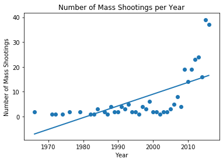

```python
X = np.array([[y] for y in lin_tab['year']])
y = lin_tab['count']
lw=2

reg = linear_model.LinearRegression()
arr = np.array([[y] for y in lin_tab['year']])
fig, ax = plt.subplots()
ax.plot(X, reg.fit(X, y).predict(X), lw=lw)
ax.scatter(X,y)

ax.set_title("Number of Mass Shootings per Year")
ax.set_ylabel("Number of Mass Shootings")
ax.set_xlabel("Year")
```

While this approach is simple and often effective, isnt a great fit for our data. The nummber of shootings has exploded in recent times, and as a result the counts are not very linear and, therefore, are not predicted well by just a line. Lets try to remedy this with polynomial regression.

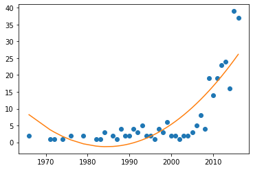

```python
plt.plot(X,y,'o')

poly = PolynomialFeatures(degree=2)
poly_years = poly.fit_transform(X)
reg.fit(poly_years, y)

poly_pred = reg.predict(poly_years)
plt.plot(X,poly_pred)
```

Using a degree two polynomial we can fit our data better than before, but there is still room for improvement. The jump in our data is more steep and we don't start with a dip in values. To try to get a steeper curve, lets increase the degree of the polynomial we are trying to match.

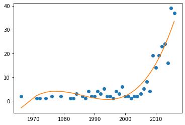

```python
plt.plot(X,y,'o')

poly = PolynomialFeatures(degree=3)
poly_years = poly.fit_transform(X)
reg.fit(poly_years, y)

poly_pred = reg.predict(poly_years)
plt.plot(X,poly_pred)
```

Finally using a thrid degree polynomial we get the best match for our data. This will likely be the best predictor of mass shootings going forward. While it is unlikely that this sharp spike in shootings continues, it is difficult to know when it will taper off. Again this increase in number could also be partly due to the inrease in awareness of the phenomena and more careful tracking of events. But it is unlikely that this is only cause, and the topic is still and area in desperate need of attension.

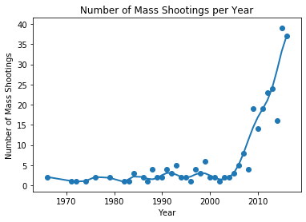

```python
svr = SVR(kernel='rbf', C=100, gamma=0.05, epsilon=.1)
fig, ax = plt.subplots()
ax.plot(X, svr.fit(X, y).predict(X), lw=lw)
ax.scatter(X,y)

ax.set_title("Number of Mass Shootings per Year")
ax.set_ylabel("Number of Mass Shootings")
ax.set_xlabel("Year")
```

Lastly, to get an even more acurate match for our data we used an SVR or Support Vector Regression. As you can see this form of regression creates a very close fit to the data, however, becuase it is fit so closely it is very prone to overfitting. Overfitting meaning that it is following the dataset too closely and therefore would not be a good predictor of future data. This is likely and issue here considering that our data set is not very large, so splitting it effectively for testing and iteration becomes difficult.

## 4. Conclusion

From this analysis, we can safely say that the United States is in a state of emergency. The last 15 years mark a new age of frequent mass shootings. Interestingly, the mean total victims is going down, which was contrary to our expectations. California and Texas represented most of the mass shootings, however, when adjusted for population, one can conclude that Washington, New Mexico, and Alabama are particularly bad when it comes to mass shootings.

## 5. References

- Lankford, Adam (2016). Public Mass Shooters and Firearms: A Cross-National Study of 171 Countries https://www.ingentaconnect.com/contentone/springer/vav/2016/00000031/00000002/art00001
- https://pandas.pydata.org/pandas-docs/version/0.23.4/generated/pandas.DataFrame.plot.html
- https://scikit-learn.org/stable/user_guide.html
- https://www.census.gov/quickfacts/fact/table/US/PST045218
- https://www.census.gov/data/datasets/time-series/demo/popest/2010s-state-total.html#par_textimage_1873399417